# PUBHBIO 6211: Practice Exercises Block 10

# Exercise 1

The survival times (in months) for 10 AIDS patients are as follows (*=censored):

$0.5* ,1,1,1,2,5* ,8* ,9,10* ,12*$

1. A Kaplan-Meier curve was generated for these data using Stata. Use this to estimate the median survival time.

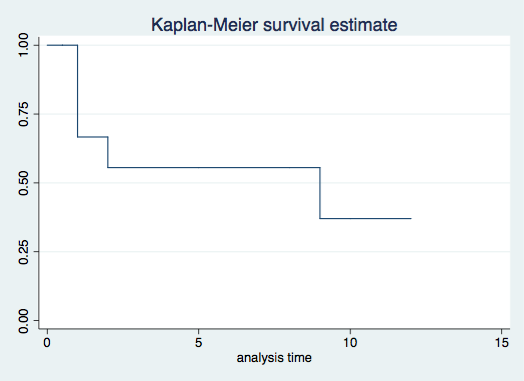

Kaplan-Meier Plot

The estimated survival function was obtained in Stata.

```stata
. sts list

         failure _d:  died
   analysis time _t:  months

           Beg.          Net            Survivor      Std.
  Time    Total   Fail   Lost           Function     Error     [95% Conf. Int.]
-------------------------------------------------------------------------------
    .5       10      0      1             1.0000         .          .         .
     1        9      3      0             0.6667    0.1571     0.2817    0.8783
     2        6      1      0             0.5556    0.1656     0.2042    0.8045
     5        5      0      1             0.5556    0.1656     0.2042    0.8045
     8        4      0      1             0.5556    0.1656     0.2042    0.8045
     9        3      1      0             0.3704    0.1872     0.0677    0.6933
    10        2      0      1             0.3704    0.1872     0.0677    0.6933
    12        1      0      1             0.3704    0.1872     0.0677    0.6933
-------------------------------------------------------------------------------
```

2. What is the estimated survival probability at 1 month? At 5 months? At 6 months?
3. Use the Stata output to confirm your answer to (a).

# Exercise 2

An observational study of mortality (time to death) for breast cancer patients was conducted. Patients were classified into two groups based on their tumor’s immunohistochemical response (0=negative; 1=positive). Time to death or censoring was recorded in months.

The survival function estimate was separately for each group and a Kaplan-Meier plot created. A logrank test was also conducted. Stata output is below. Use that output to answer the following questions.

```stata
. sts list, by(group)

           Beg.          Net            Survivor      Std.
  Time    Total   Fail   Lost           Function     Error     [95% Conf. Int.]
-------------------------------------------------------------------------------
negative
    19       36      1      0             0.9722    0.0274     0.8187    0.9960
    25       35      1      0             0.9444    0.0382     0.7957    0.9858
    30       34      1      0             0.9167    0.0461     0.7635    0.9723
    34       33      1      0             0.8889    0.0524     0.7305    0.9568
    37       32      1      0             0.8611    0.0576     0.6980    0.9397
    46       31      1      0             0.8333    0.0621     0.6661    0.9214
    47       30      1      0             0.8056    0.0660     0.6350    0.9022
    51       29      1      0             0.7778    0.0693     0.6044    0.8821
    56       28      1      0             0.7500    0.0722     0.5746    0.8613
    57       27      1      0             0.7222    0.0747     0.5453    0.8398
    61       26      1      0             0.6944    0.0768     0.5165    0.8177
    66       25      1      0             0.6667    0.0786     0.4883    0.7950
    67       24      1      0             0.6389    0.0801     0.4607    0.7718
    74       23      1      0             0.6111    0.0812     0.4335    0.7482
    78       22      1      0             0.5833    0.0822     0.4067    0.7240
    86       21      1      0             0.5556    0.0828     0.3805    0.6994
   122       20      0      1             0.5556    0.0828     0.3805    0.6994
   123       19      0      1             0.5556    0.0828     0.3805    0.6994
   130       18      0      2             0.5556    0.0828     0.3805    0.6994
   133       16      0      1             0.5556    0.0828     0.3805    0.6994
   134       15      0      1             0.5556    0.0828     0.3805    0.6994
   136       14      0      1             0.5556    0.0828     0.3805    0.6994
   141       13      0      1             0.5556    0.0828     0.3805    0.6994
   143       12      0      1             0.5556    0.0828     0.3805    0.6994
   148       11      0      1             0.5556    0.0828     0.3805    0.6994
   151       10      0      1             0.5556    0.0828     0.3805    0.6994
   152        9      0      1             0.5556    0.0828     0.3805    0.6994
   153        8      0      1             0.5556    0.0828     0.3805    0.6994
   154        7      0      1             0.5556    0.0828     0.3805    0.6994
   156        6      0      1             0.5556    0.0828     0.3805    0.6994
   162        5      0      1             0.5556    0.0828     0.3805    0.6994
   164        4      0      1             0.5556    0.0828     0.3805    0.6994
   165        3      0      1             0.5556    0.0828     0.3805    0.6994
   182        2      0      1             0.5556    0.0828     0.3805    0.6994
   189        1      0      1             0.5556    0.0828     0.3805    0.6994
positive
    22        9      1      0             0.8889    0.1048     0.4330    0.9836
    23        8      1      0             0.7778    0.1386     0.3648    0.9393
    38        7      1      0             0.6667    0.1571     0.2817    0.8783
    42        6      1      0             0.5556    0.1656     0.2042    0.8045
    73        5      1      0             0.4444    0.1656     0.1359    0.7193
    77        4      1      0             0.3333    0.1571     0.0783    0.6226
    89        3      1      0             0.2222    0.1386     0.0337    0.5131
   115        2      1      0             0.1111    0.1048     0.0061    0.3877
   144        1      0      1             0.1111    0.1048     0.0061    0.3877
-------------------------------------------------------------------------------
```

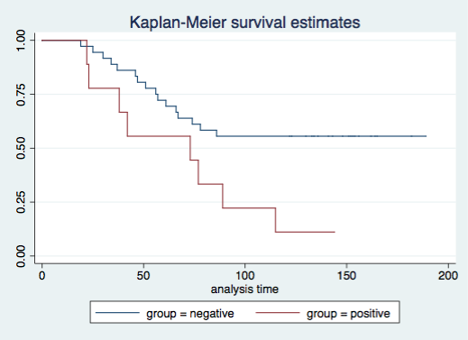

Kaplan-Meier Plot by Group

```stata
. sts test group, logrank

Log-rank test for equality of survivor functions

         |   Events         Events
group    |  observed       expected
---------+-------------------------
negative |        16          20.19
positive |         8           3.81
---------+-------------------------
Total    |        24          24.00

               chi2(1) =       5.49
               Pr>chi2 =     0.0191
```

1. What is the estimated 25th percentile of survival for each group? Interpret these quantities.
2. What is the estimated survival probability for each group at 2 years (24 months)? At 5 years (60 months)?
3. What are the null and alternative hypotheses for the logrank test that was performed? Write down the hypotheses using symbols, and also explain in words what the null and alternative hypotheses mean.
4. Report the p-value for the logrank test and write a one-sentence conclusion (in context). (Assume $\alpha=0.05$)

# Exercise 3

An observational study of survival of patients with cancer of the larynx was conducted. There were a total of 90 patients in the study, and for each patient we have information on the stage of cancer he/she has (stage = 1, 2, 3, 4). We also have the time in months until the patient died, was lost to follow-up, or was censored.

1. Below is a Kaplan-Meier plot of these data. Describe what you see in terms of how survival might differ by cancer stage. (Which one has the “best” survival? Which one the “worst”?) Remember that you’re not doing a test – just describing what you see.

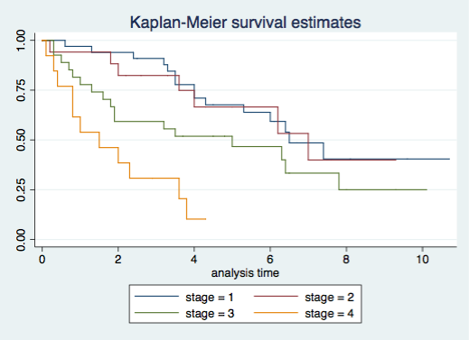

Kaplan-Meier Plot by Cancer Stage

2. Using the plot, roughly approximate the median survival for each group.
3. A logrank test was conducted; output is below. Write a one-sentence summary of the test result (in context), including reference to a p-value. (Assume $\alpha=0.05$)

```stata
. sts test stage, logrank

Log-rank test for equality of survivor functions

      |   Events         Events
stage |  observed       expected
------+-------------------------
1     |        15          22.57
2     |         7          10.01
3     |        17          14.08
4     |        11           3.34
------+-------------------------
Total |        50          50.00

            chi2(3) =      22.76
            Pr>chi2 =     0.0000
```